# PML Assignment

Daniele Pigni

25 October 2015

# Background

This report explores how data from accelerometers on the belt, forearm, arm and dumbell of 6 participants predict the manner in which participants did several exercises.

Datas are collected by devices such as Jawbone Up, Nike FuelBand, and Fitbit. These type of devices are part of the quantified self movement – a group of enthusiasts who take measurements about themselves regularly to improve their health, to find patterns in their behavior, or because they are tech geeks.

One thing that people regularly do is quantify how much of a particular activity they do, but they rarely quantify how well they do it. That’s what I’ll explore in this report.

The dependent variable or response is the “classe” variable in the training set.

# Data

## Read Data

The training data for this project are available here: https://d396qusza40orc.cloudfront.net/predmachlearn/pml-training.csv

The test data are available here: https://d396qusza40orc.cloudfront.net/predmachlearn/pml-testing.csv

The data for this project comes from this original source: http://groupware.les.inf.puc-rio.br/har.

The following instructions will load the required libraries and will read the training and testing datasets, assigning missing values to entries that are currently ‘NA’ or blank.

```r
set.seed(123)
library(caret)
library(randomForest)
training = read.csv("pml-training.csv", na.strings=c("", "NA", "NULL"))
testing = read.csv("pml-testing.csv", na.strings=c("", "NA", "NULL"))
```

## Clean Data

First step: reduce the number of predictors by exluding predictors with too many NA values

```r
training.clean1 <- training[ , colSums(is.na(training)) == 0]
```

Second step: remove unrelevant columns for the analysis

```r
training.clean2 <- training.clean1[, -c(1:7)]
```

## Split Data

I split the clean dataset (19622 obs., 53 variables) into 2 datasets: train (75%) and validate (25%).

```r
split = createDataPartition(y = training.clean2$classe, p = 0.75, list = FALSE)
train = training.clean2[split, ]
validate = training.clean2[-split, ]
```

# Train Model

```r
model <- randomForest(classe~.,data=train,ntree=100,importance=T)
model
```

```
##
## Call:
##  randomForest(formula = classe ~ ., data = train, ntree = 100,      importance = T)
##                Type of random forest: classification
##                      Number of trees: 100
## No. of variables tried at each split: 7
##
##         OOB estimate of  error rate: 0.69%
## Confusion matrix:
##      A    B    C    D    E class.error
## A 4179    4    1    0    1 0.001433692
## B   18 2825    5    0    0 0.008075843
## C    0   18 2542    7    0 0.009738995
## D    1    0   35 2373    3 0.016169154
## E    0    0    0    8 2698 0.002956393
```

Next step is to plot the output of the model to see which variable has the biggest impact.

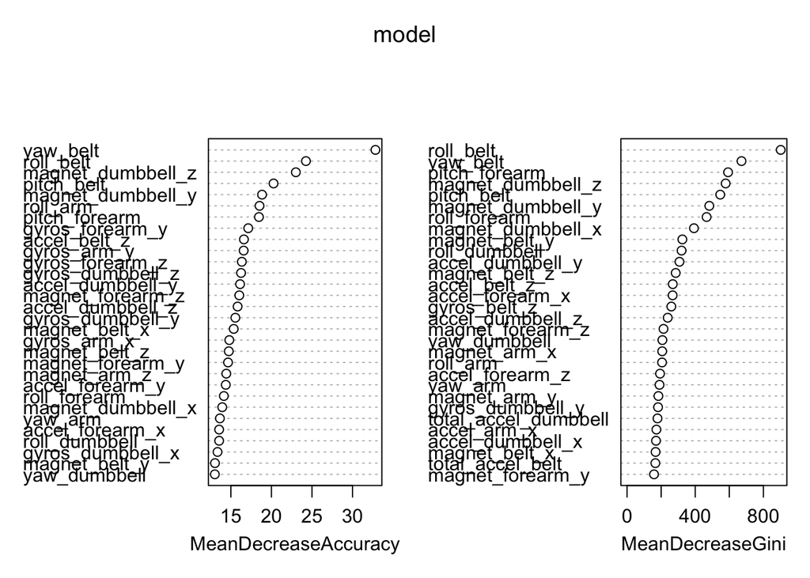

```r
varImpPlot(model,)
```

# Validate model

To check the accuracy of the model, we use the validate dataset applying the trained model and check the results with a confusion matrix.

```r
validate.prediction <- predict(model,validate,type="class")
confusionMatrix(validate.prediction,validate$classe)
```

```
## Confusion Matrix and Statistics
##
##           Reference
## Prediction    A    B    C    D    E
##          A 1394    2    0    0    0
##          B    0  947    6    0    0
##          C    0    0  848   11    0
##          D    1    0    1  793    2
##          E    0    0    0    0  899
##
## Overall Statistics
##
##                Accuracy : 0.9953
##                  95% CI : (0.993, 0.997)
##     No Information Rate : 0.2845
##     P-Value [Acc > NIR] : < 2.2e-16
##
##                   Kappa : 0.9941
##  Mcnemar's Test P-Value : NA
##
## Statistics by Class:
##
##                      Class: A Class: B Class: C Class: D Class: E
## Sensitivity            0.9993   0.9979   0.9918   0.9863   0.9978
## Specificity            0.9994   0.9985   0.9973   0.9990   1.0000
## Pos Pred Value         0.9986   0.9937   0.9872   0.9950   1.0000
## Neg Pred Value         0.9997   0.9995   0.9983   0.9973   0.9995
## Prevalence             0.2845   0.1935   0.1743   0.1639   0.1837
## Detection Rate         0.2843   0.1931   0.1729   0.1617   0.1833
## Detection Prevalence   0.2847   0.1943   0.1752   0.1625   0.1833
## Balanced Accuracy      0.9994   0.9982   0.9945   0.9927   0.9989
```

# Conclusions

Random Forest demonstrated an accuracy of 0.99 which is very high. The model is therefore accepted and used to predict the classe values of the testing set.